# Sense overlap

Sean Trott

May 6, 2020

# Introduction

Klepousniotou et al (2008) and Brown (2008) both showed that the ease of transitioning between two senses of a polysemous word depends on their **degree of overlap**. That is, there is less inhibition (greater facilitation) between *marinated lamb* and *baby lamb* than between *control panel* and *advisory panel*. They measured priming *within* a sense category as a comparison, e.g., between *marinated lamb* and *tender lamb*. Klepousniotou et al (2008) also analyzed an interaction with sense **dominance**, but I will not be analyzing that here.

In the current analyses, I adapted most of their stimuli to sentences, e.g., "He liked the marinated lamb" vs. "He liked the baby lamb". I also created new stimuli using homonyms from Klepousniotou & Baum (2007).

I then ran each sentence through ELMo and obtained contextualized embeddings for the target word, e.g., *lamb*. Finally, I computed the `cosine distance` between the two embeddings. This allows us to make several comparisons:

First, is `cosine distance` consistently larger for usages occurring *across* senses? That is, is $cos(lamb_{marinated}, lamb_{baby}) > cos(lamb_{marinated}, lamb_{tender})$? If so, it suggests that the contextualized embeddings distinguish between contexts of use in such a way as to correlate with sense boundaries.

Second, and more importantly: for usages occurring *across* senses (e.g., *baby/marinated lamb*), does `cosine distance` vary as a function of `degree of overlap`? If so, it suggests that the existence of a sense boundary isn't the only thing that matters in state-space: the *distance* (degree of overlap) between two senses or *sense-clusters* is also important. This finding would corroborrate the behavioral finding that `degree of overlap` predicts the degree of facilitation or inhibition.

Our data thus looks as follows: each observation represents a comparison (`cosine distance`) between two identical wordforms appearing in different contexts. Roughly 1/3 of these observations reflect **same sense** contexts; roughly 2/3 reflect **different sense** contexts. Furthermore, `condition` reflects the degree of overlap between the different sense-contexts.

Random factors include:

- Each `word`
- The `source` (confounded with `POS`, verb vs. noun)

For both factors, we include by-factor random slopes for the effect of `same sense` (though *not* `condition`).

# Load data

```r
setwd("/Users/seantrott/Dropbox/UCSD/Research/Ambiguity/SSD/polysemy_homonymy")
df_distances = read_csv("data/processed/stims_processed.csv")
nrow(df_distances)
```

```
## [1] 684
```

```r
table(df_distances$same)
```

```
##
## FALSE  TRUE
##   456   228
```

```r
table(df_distances$same) / nrow(df_distances)
```

```
##
##     FALSE      TRUE
## 0.6666667 0.3333333
```

Additionally, the Brown (2008) stimuli have different condition labels:

```r
table(df_distances$condition)
```

```
##
##            close          distant     high overlap          homonym
##               66               66              132              150
##      low overlap moderate overlap
##              132              138
```

For our purposes here, let's merge them. This is a very rough approximation, and we might need to do a more principled way of merging them later on.

```r
df_distances$condition_merged = fct_recode(
  df_distances$condition,
  "high overlap" = "close",
  "low overlap" = "distant"
)
```

# Primary analyses

## Is cosine distance larger for usages across senses?

**TODO**: Take out random effect for "version"? Correlated with `same`.

First, we ask whether the existence of a sense boundary explains significant variance in the `cosine distance` between two words.

```r
model_same = lmer(data = df_distances,
                  distance ~ same +
                    (1 + same | word) +
                    (1 + same | source),
                  control=lmerControl(optimizer="bobyqa"),
                  REML=FALSE)
```

```
## boundary (singular) fit: see ?isSingular
```

```r
model_null = lmer(data = df_distances,
                  distance ~
                    (1 + same | word) +
                    (1 + same | source),
                  control=lmerControl(optimizer="bobyqa"),
                  REML=FALSE)
```

```
## boundary (singular) fit: see ?isSingular
```

```r
summary(model_same)
```

```
## Linear mixed model fit by maximum likelihood  ['lmerMod']
## Formula: distance ~ same + (1 + same | word) + (1 + same | source)
##    Data: df_distances
## Control: lmerControl(optimizer = "bobyqa")
##
##      AIC      BIC   logLik deviance df.resid
##  -2536.9  -2496.1   1277.4  -2554.9      675
##
## Scaled residuals:
##     Min      1Q  Median      3Q     Max
## -4.3190 -0.4887 -0.0212  0.4086  8.1419
##
## Random effects:
##  Groups   Name        Variance  Std.Dev. Corr
##  word     (Intercept) 0.0014414 0.03797
##           sameTRUE    0.0006303 0.02510  -1.00
##  source   (Intercept) 0.0003704 0.01925
##           sameTRUE    0.0002392 0.01546  -1.00
##  Residual             0.0010082 0.03175
## Number of obs: 684, groups:  word, 109; source, 3
##
## Fixed effects:
##              Estimate Std. Error t value
## (Intercept)  0.116845   0.012008   9.731
## sameTRUE    -0.048214   0.009772  -4.934
##
## Correlation of Fixed Effects:
##          (Intr)
## sameTRUE -0.974
## convergence code: 0
## boundary (singular) fit: see ?isSingular
```

```r
anova(model_same, model_null)
```

```
## Data: df_distances
## Models:
## model_null: distance ~ (1 + same | word) + (1 + same | source)
## model_same: distance ~ same + (1 + same | word) + (1 + same | source)
##            npar     AIC     BIC logLik deviance Chisq Df Pr(>Chisq)
## model_null    8 -2532.1 -2495.9 1274.1  -2548.1
## model_same    9 -2536.9 -2496.1 1277.4  -2554.9 6.748  1   0.009385 **
## ---
## Signif. codes:  0 '***' 0.001 '**' 0.01 '*' 0.05 '.' 0.1 ' ' 1
```

We find that it does. We can illustrate this visually as well:

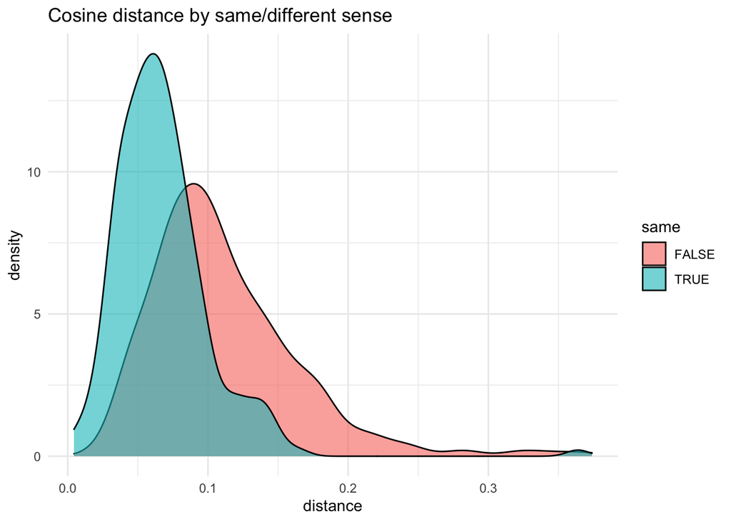

```r
df_distances %>%
  ggplot(aes(x = distance,
             fill = same)) +
  geom_density(alpha = .6) +
  labs(title = "Cosine distance by same/different sense") +
  theme_minimal()
```

## Does cosine distance vary as a function of degree of overlap?

Above, we saw that the cosine distance between two usages varied as a function of whether those usages belonged to the same sense.

But is there further variance to be explained as a function of the **degree of overlap** between two different senses?

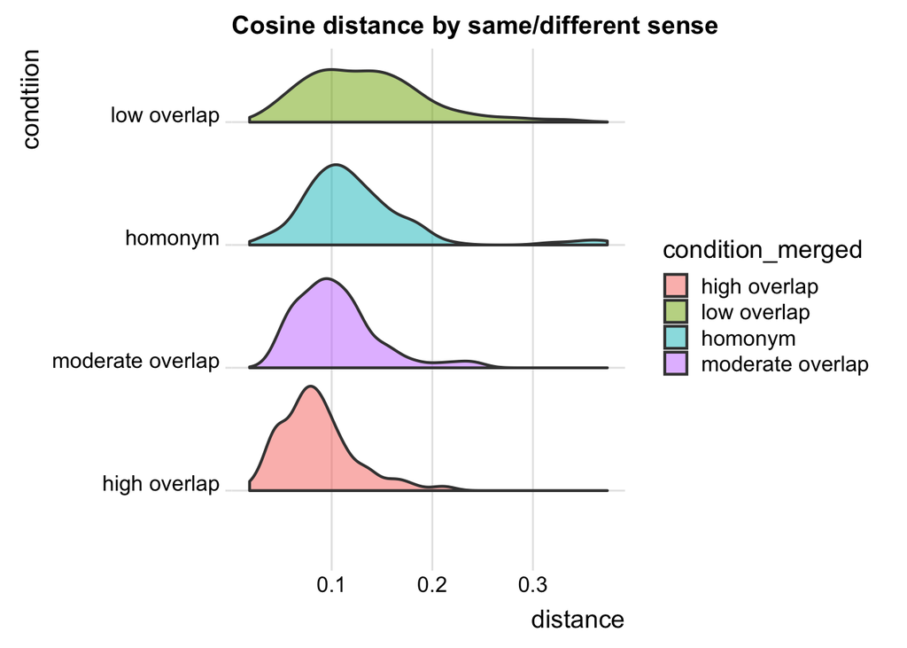

```r
df_distances %>%
  filter(same == FALSE) %>%
  ggplot(aes(x = distance,
             y = reorder(condition_merged, distance),
             fill = condition_merged)) +
   geom_density_ridges2(aes(height = ..density..), color=gray(0.25), alpha = 0.5, scale=0.85, size=0.75, stat="density") +
  labs(title = "Cosine distance by same/different sense",
       y = "condtiion") +
  theme_ridges()
```

First, we demonstrate that `condition` explains variance above and beyond a null model.

```r
model_overlap = lmer(data = df_distances,
                     distance ~ condition_merged +
                    (1 + same | word) +
                    (1 + same | source),
                     control=lmerControl(optimizer="bobyqa"),
                     REML=FALSE)

model_null = lmer(data = df_distances,
                  distance ~
                    (1 + same | word) +
                    (1 + same | source),
                  control=lmerControl(optimizer="bobyqa"),
                  REML=FALSE)
```

```
## boundary (singular) fit: see ?isSingular
```

```r
summary(model_overlap)
```

```
## Linear mixed model fit by maximum likelihood  ['lmerMod']
## Formula: distance ~ condition_merged + (1 + same | word) + (1 + same |
##     source)
##    Data: df_distances
## Control: lmerControl(optimizer = "bobyqa")
##
##      AIC      BIC   logLik deviance df.resid
##  -2576.5  -2526.7   1299.3  -2598.5      673
##
## Scaled residuals:
##     Min      1Q  Median      3Q     Max
## -3.8028 -0.4786 -0.0383  0.4245  7.5725
##
## Random effects:
##  Groups   Name        Variance  Std.Dev. Corr
##  word     (Intercept) 0.0012500 0.03536
##           sameTRUE    0.0007045 0.02654  -0.91
##  source   (Intercept) 0.0042109 0.06489
##           sameTRUE    0.0025240 0.05024  -0.99
##  Residual             0.0009047 0.03008
## Number of obs: 684, groups:  word, 109; source, 3
##
## Fixed effects:
##                                  Estimate Std. Error t value
## (Intercept)                      0.027427   0.006698   4.095
## condition_mergedlow overlap      0.032043   0.005559   5.764
## condition_mergedhomonym          0.040816   0.006928   5.891
## condition_mergedmoderate overlap 0.031845   0.006900   4.615
##
## Correlation of Fixed Effects:
##              (Intr) cndtn_mrgdlo cndtn_
## cndtn_mrgdlo -0.365
## cndtn_mrgdh  -0.446  0.260
## cndtn_mrgdmo -0.288  0.395        0.161
```

```r
anova(model_overlap, model_null)
```

```
## Data: df_distances
## Models:
## model_null: distance ~ (1 + same | word) + (1 + same | source)
## model_overlap: distance ~ condition_merged + (1 + same | word) + (1 + same |
## model_overlap:     source)
##               npar     AIC     BIC logLik deviance  Chisq Df Pr(>Chisq)
## model_null       8 -2532.1 -2495.9 1274.1  -2548.1
## model_overlap   11 -2576.5 -2526.7 1299.2  -2598.5 50.377  3  6.641e-11 ***
## ---
## Signif. codes:  0 '***' 0.001 '**' 0.01 '*' 0.05 '.' 0.1 ' ' 1
```

We also show that a model with both `condition` and `same` explains more variance than a model with only one of those factors.

```r
model_both = lmer(data = df_distances,
                     distance ~ condition_merged +
                       same +
                    (1 + same | word) +
                    # (1 + same | version) +
                    (1 + same | source),
                     control=lmerControl(optimizer="bobyqa"),
                     REML=FALSE)

anova(model_both, model_same)
```

```
## Data: df_distances
## Models:
## model_same: distance ~ same + (1 + same | word) + (1 + same | source)
## model_both: distance ~ condition_merged + same + (1 + same | word) + (1 +
## model_both:     same | source)
##            npar     AIC     BIC logLik deviance  Chisq Df Pr(>Chisq)
## model_same    9 -2536.9 -2496.1 1277.4  -2554.9
## model_both   12 -2581.1 -2526.8 1302.6  -2605.1 50.239  3  7.106e-11 ***
## ---
## Signif. codes:  0 '***' 0.001 '**' 0.01 '*' 0.05 '.' 0.1 ' ' 1
```

```r
anova(model_both, model_overlap)
```

```
## Data: df_distances
## Models:
## model_overlap: distance ~ condition_merged + (1 + same | word) + (1 + same |
## model_overlap:     source)
## model_both: distance ~ condition_merged + same + (1 + same | word) + (1 +
## model_both:     same | source)
##               npar     AIC     BIC logLik deviance  Chisq Df Pr(>Chisq)
## model_overlap   11 -2576.5 -2526.7 1299.2  -2598.5
## model_both      12 -2581.1 -2526.8 1302.6  -2605.1 6.6101  1    0.01014 *
## ---
## Signif. codes:  0 '***' 0.001 '**' 0.01 '*' 0.05 '.' 0.1 ' ' 1
```

There is also an interaction between `condition` and `same`.

```r
model_interaction = lmer(data = df_distances,
                     distance ~ condition_merged * same +
                    (1 + same | word) +
                    # (1 + same | version) +
                    (1 + same | source),
                     control=lmerControl(optimizer="bobyqa"),
                     REML=FALSE)
```

```
## boundary (singular) fit: see ?isSingular
```

```r
anova(model_both, model_interaction)
```

```
## Data: df_distances
## Models:
## model_both: distance ~ condition_merged + same + (1 + same | word) + (1 +
## model_both:     same | source)
## model_interaction: distance ~ condition_merged * same + (1 + same | word) + (1 +
## model_interaction:     same | source)
##                   npar     AIC     BIC logLik deviance  Chisq Df Pr(>Chisq)
## model_both          12 -2581.1 -2526.8 1302.6  -2605.1
## model_interaction   15 -2606.8 -2538.9 1318.4  -2636.8 31.667  3  6.151e-07 ***
## ---
## Signif. codes:  0 '***' 0.001 '**' 0.01 '*' 0.05 '.' 0.1 ' ' 1
```

```r
summary(model_interaction)
```

```
## Linear mixed model fit by maximum likelihood  ['lmerMod']
## Formula: distance ~ condition_merged * same + (1 + same | word) + (1 +
##     same | source)
##    Data: df_distances
## Control: lmerControl(optimizer = "bobyqa")
##
##      AIC      BIC   logLik deviance df.resid
##  -2606.8  -2538.9   1318.4  -2636.8      669
##
## Scaled residuals:
##     Min      1Q  Median      3Q     Max
## -3.4188 -0.4900 -0.0553  0.4586  8.1922
##
## Random effects:
##  Groups   Name        Variance  Std.Dev. Corr
##  word     (Intercept) 0.0012996 0.03605
##           sameTRUE    0.0006157 0.02481  -0.97
##  source   (Intercept) 0.0006347 0.02519
##           sameTRUE    0.0003133 0.01770  -1.00
##  Residual             0.0008773 0.02962
## Number of obs: 684, groups:  word, 109; source, 3
##
## Fixed effects:
##                                            Estimate Std. Error t value
## (Intercept)                                0.070786   0.016052   4.410
## condition_mergedlow overlap                0.052801   0.008051   6.558
## condition_mergedhomonym                    0.069873   0.009736   7.177
## condition_mergedmoderate overlap           0.036865   0.010737   3.434
## sameTRUE                                  -0.019551   0.011997  -1.630
## condition_mergedlow overlap:sameTRUE      -0.033738   0.008069  -4.181
## condition_mergedhomonym:sameTRUE          -0.047877   0.009321  -5.136
## condition_mergedmoderate overlap:sameTRUE -0.011470   0.009798  -1.171
##
## Correlation of Fixed Effects:
##                         (Intr) cndtn_mrgdlo cndtn_ cndtn_mrgdmo smTRUE
## cndtn_mrgdlo            -0.195
## cndtn_mrgdh             -0.278  0.175
## cndtn_mrgdmo            -0.147  0.371        0.084
## sameTRUE                -0.946  0.195        0.276  0.144
## cndtn_mrgdlovrlp:smTRUE  0.147 -0.734       -0.146 -0.272       -0.302
## cndtn_:TRUE              0.216 -0.147       -0.776 -0.072       -0.348
## cndtn_mrgdmovrlp:smTRUE  0.120 -0.300       -0.083 -0.785       -0.247
##                         cndtn_mrgdlovrlp:smTRUE c_:TRU
## cndtn_mrgdlo
## cndtn_mrgdh
## cndtn_mrgdmo
## sameTRUE
## cndtn_mrgdlovrlp:smTRUE
## cndtn_:TRUE              0.318
## cndtn_mrgdmovrlp:smTRUE  0.410                   0.232
## convergence code: 0
## boundary (singular) fit: see ?isSingular
```

Looking at the coefficients, we can see:

- A main effect of `same` (same-sense pairs are closer in vector-space than different-sense pairs).
- A main effect of `condition` (`moderate overlap` pairs are further than `high overlap`; `low overlap` are further than `moderate overlap`; and `homonymys` are further than `low overlap`).
- Interactions: For these levels of `condition`, word pairs are closer when they're used in the same sense (as you'd expect).

We can also copare the model's predictions against the real values for cosine distance.

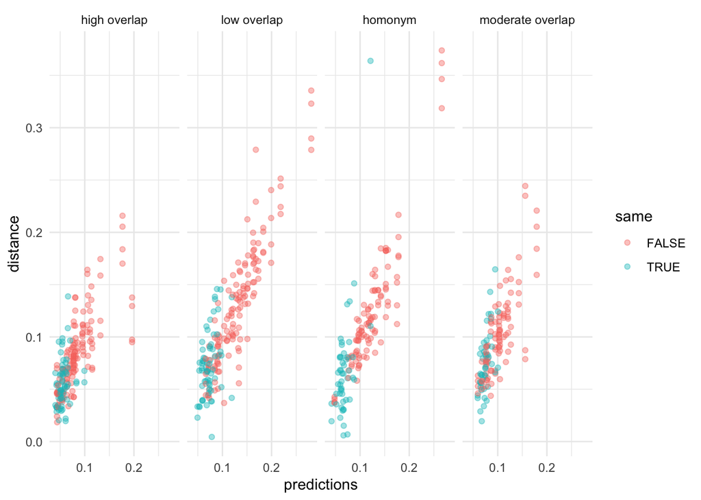

```r
df_distances$predictions = predict(model_interaction)


df_distances %>%
  ggplot(aes(x = predictions,
             y = distance,
             color = same)) +
  geom_point(alpha = .4) +
  facet_grid(~condition_merged) +
  theme_minimal()
```

# Exploratory analyses and visualizations

First, let's look at the Brown (2008) data. According to this visualization, it *looks* like same-sense pairs are quite close across the board. The distance between different-sense pairs grows according to Brown's (2008) condition labels; the distance between different-sense pairs is perhaps a little greater for `distant` pairs than `homonyms`.

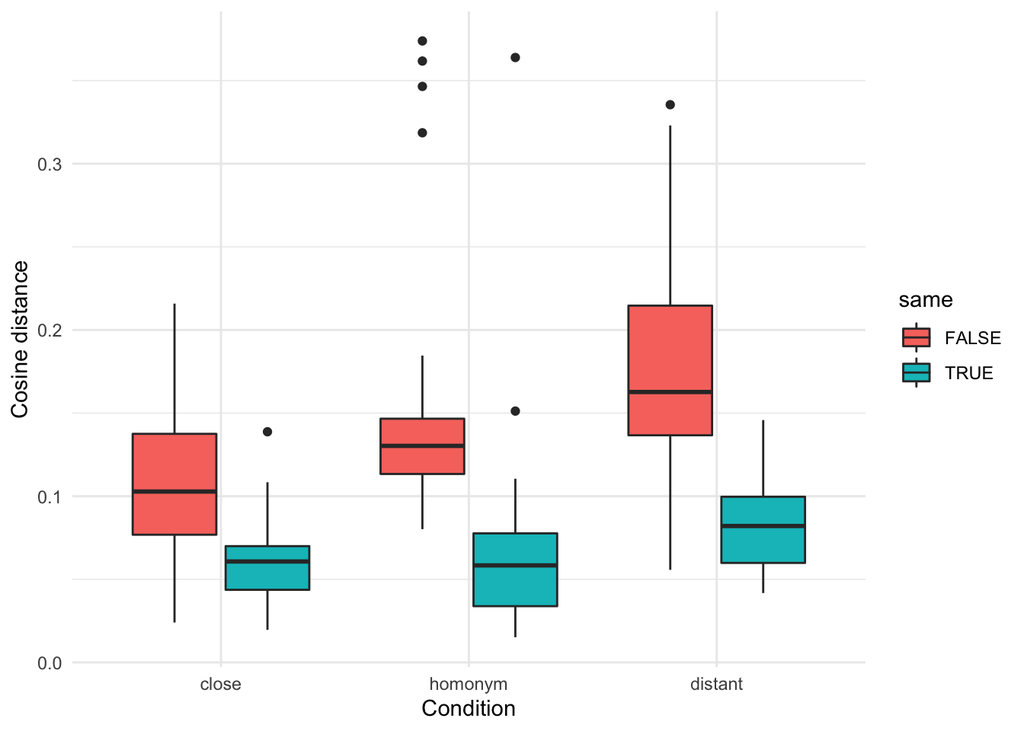

```r
df_distances %>%
  filter(source == "Brown(2008)") %>%
  ggplot(aes(x = reorder(condition, distance),
             y = distance,
             fill = same)) +
  geom_boxplot() +
  labs(x = "Condition",
       y = "Cosine distance") +
  theme_minimal()
```

Now let's look at Klepousniotou et al (2008) specifically. Pretty similar pattern here, although we see a stronger effect of `condition` on the **same sense** pairs (which is puzzling; see discussion below).

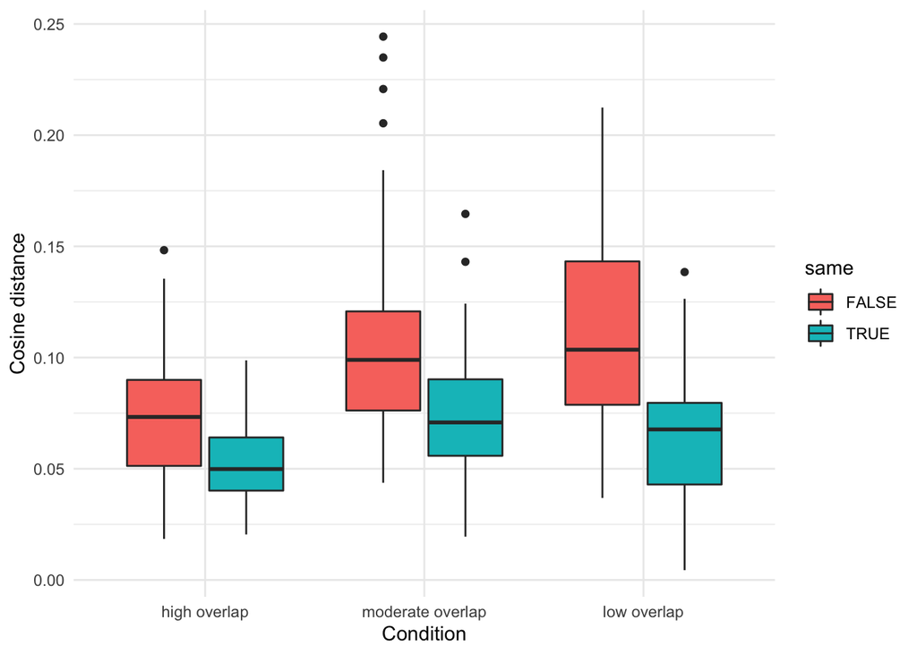

```r
df_distances %>%
  filter(source == "Klepousniotou et al (2008)") %>%
  ggplot(aes(x = reorder(condition, distance),
             y = distance,
             fill = same)) +
  geom_boxplot() +
  labs(x = "Condition",
       y = "Cosine distance") +
  theme_minimal()
```

Now let's just look at them altogether:

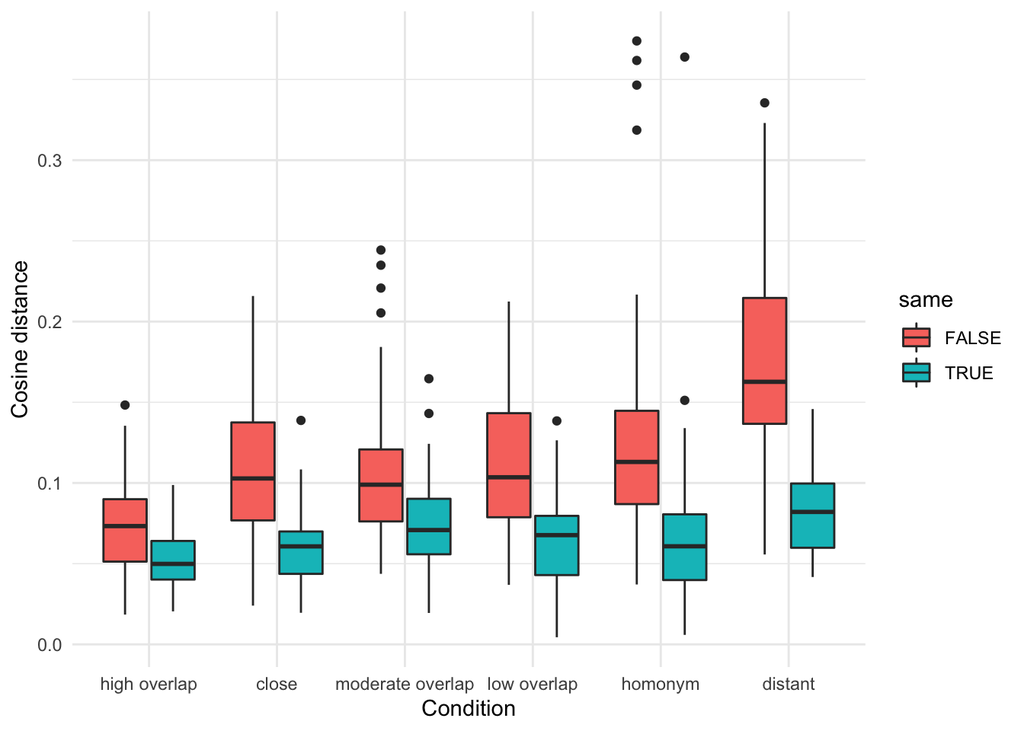

```r
df_distances %>%
  # filter(source == "Klepousniotou et al (2008)") %>%
  ggplot(aes(x = reorder(condition, distance),
             y = distance,
             fill = same)) +
  geom_boxplot() +
  labs(x = "Condition",
       y = "Cosine distance") +
  theme_minimal()
```

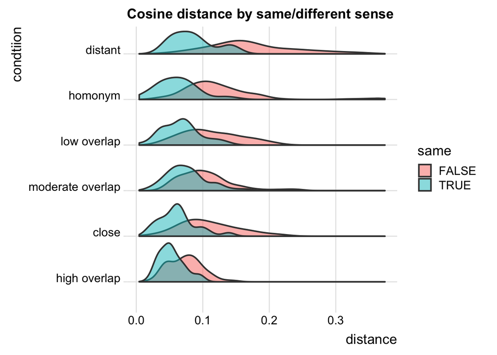

```r
df_distances %>%
  # filter(same == "False") %>%
  ggplot(aes(x = distance,
             y = reorder(condition, distance),
             fill = same)) +
   geom_density_ridges2(aes(height = ..density..), color=gray(0.25), alpha = 0.5, scale=0.85, size=0.75, stat="density") +
  labs(title = "Cosine distance by same/different sense",
       y = "condtiion") +
  theme_ridges()
```

# Questions and limitations

Overall, these findings are encouraging given that they are consistent (qualitatively) with the findings of Klepousniotou et al (2008) and Brown (2008).

One odd finding, however, is that **degree of overlap** predicts `cosine distance` for words both *within* and *across* sense boundaries. I'm not sure why this would be. Theoretically, the distance between two usages in the *same* sense shouldn't vary as a function of how far apart that sense is from *other* senses of the word. But we see very similar patterns for **degree of overlap** for both levels of `same` (`False/True`). (Importantly, though, **same sense** is always closer in vector-space than **different sense**, regardless of degree of overlap.)